# HUGEN 2072 Project 3

# Instructions

Below is a guided tutorial to perform a genome-wide association study (GWAS) of height. Some code has been provided to you and some you will need to write yourself.

Project 3 has three components:

- **Scripting/coding**: read through this file and complete the pipeline by contributing your code *where indicated*.
- **Narrative**: knit the completed .Rmd to a code-integrated HTML report of your QC process and decisions.
  - Your report must answer all the questions and perform all the tasks indicated in the instructions/prompts given for each step.
  - You must submit a successfully-knitted HTML file and the `.Rmd` in order to earn a passing grade for this project.
  - Set up your report to flow like an actual document you might show your supervisor to summarize the QC project, emphasizing what was done at each step rather than the code used to do it (e.g., how many samples/SNPs were filtered out at a given step?)
  - **Submit your .Rmd and HTML to Canvas**
- **Presentation**: you will make a 10-min (maximum) recording of yourself with Panopto in which you summarize this GWAS. Instructions will given on Canvas.

In each part of this project you will implement one of the main steps of GWAS (some steps completed for you).

**Since the pipeline below is incomplete, some of the R code chunks are set to `eval=FALSE` so that knitting to HTML will succeed. You will need to change them to `eval=TRUE` as you progress so that your knitted document shows the results of running each chunk.**

**However, some chunks are very computationally intensive, produce a file that can be used without re-running the chunk. To make knitting to HTML faster, I have indicated which chunks you can set to `eval=FALSE` after you have produced the required files.**

**It is expected that you will copy this file somewhere to your directory on the CRC cluster so that you can use the RStudio Server, where all the packages you need have been installed already.**

## Part 0 - Setup Workspace and Load Sample Data

First, load the packages we’ll be using.

```r
# Load the required packages for the project (Install them if necessary)

library("tidyverse", quietly = TRUE)
library("GWASTools", quietly = TRUE)
library("GWASdata", quietly = TRUE)
library("SNPRelate", quietly = TRUE)
library("GENESIS", quietly = TRUE)
library("GGally", quietly = TRUE)
library("qqman", quietly = TRUE)
library("psych", quietly = TRUE) #for pairwise plot
# Close any open GDS files before proceeding (think of this as starting off with a 'blank slate')

showfile.gds(closeall = T, verbose = T)
```

All of the files you will need are located on the cluster in `/ix1/hugen2072_2025s/p3/`.

```
p3_sample_info.RData
p3_variant_info.RData
p3_pca.RData
p3_grm.RData
p3_imputed_data.gds
```

To start, load in the sample information file and examine it.

```r
# path to folder for project
my_folder <- "/ix1/hugen2072-2025s/p3/"
#my_folder <- "/bgfs/jcarlson/hugen2072/project3_GWAS/files_for_students/"

# load the sample info file
load(paste0(my_folder, "p3_sample_info.RData"), verbose = TRUE)
```

```
## Loading objects:
##   sample.info
```

```r
# what type of data file is sample.info
class(sample.info)
```

```
## [1] "ScanAnnotationDataFrame"
## attr(,"package")
## [1] "GWASTools"
```

```r
# examine contents
head(pData(sample.info))
```

```
##    scanID sex pop   height
## 1 HG00096   M EUR 170.5518
## 2 HG00097   F EUR 155.1560
## 3 HG00099   F EUR 157.5750
## 4 HG00100   F EUR 151.2360
## 5 HG00101   M EUR 161.9721
## 6 HG00102   F EUR 148.3681
```

## Part 0 - Report

Describe the sample to use in this study. How many individuals are there? What measurements (variables) are there?

Describe the distribution of the phenotype height. Does it vary by sex or population (pop)?

Based on your findings, do you think you should include sex or pop as covariates in a GWAS for height?

```r
# Your code goes here

#Part-0 qn-1 : Describe the sample to use in this study. How many individuals are there? What measurements (variables) are there?
#Ans-1: There are 2548 individuals in this study and 4 variables(scanID, sex, pop and height)
dim(pData(sample.info))
```

```
## [1] 2548    4
```

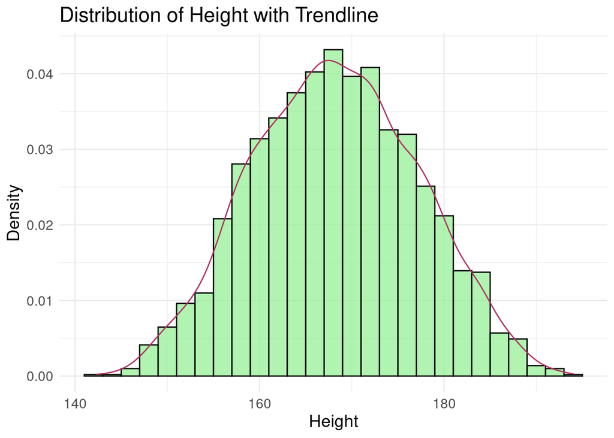

```r
#Part-0 qn-2 : Describe the distribution of the phenotype height. Does it vary by sex or population (pop)?
#Ans-2 : The distribution of height is normal distribution. Height varies by sex and population.
ggplot(pData(sample.info), aes(x = height)) +
  geom_histogram(aes(y = after_stat(density)), binwidth = 2, fill = "lightgreen", color = "black", alpha = 0.7) +
  geom_density(color = "maroon", linewidth = 0.5) +
  theme_minimal() +
  labs(title = "Distribution of Height with Trendline",
       x = "Height",
       y = "Density") +
  theme(text = element_text(size = 14))
```

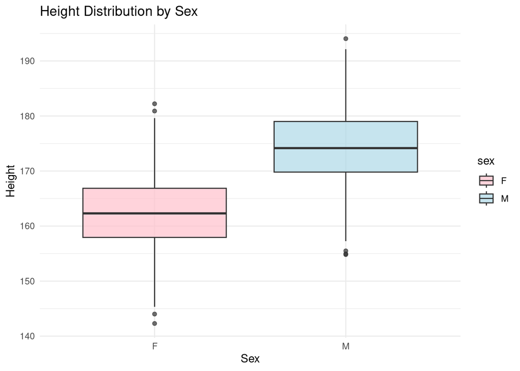

```r
ggplot(pData(sample.info), aes(x = sex, y = height, fill = sex)) +
  geom_boxplot(alpha = 0.7) +
  theme_minimal() +
  labs(title = "Height Distribution by Sex", x = "Sex", y = "Height") +
  scale_fill_manual(values = c("pink", "lightblue"))
```

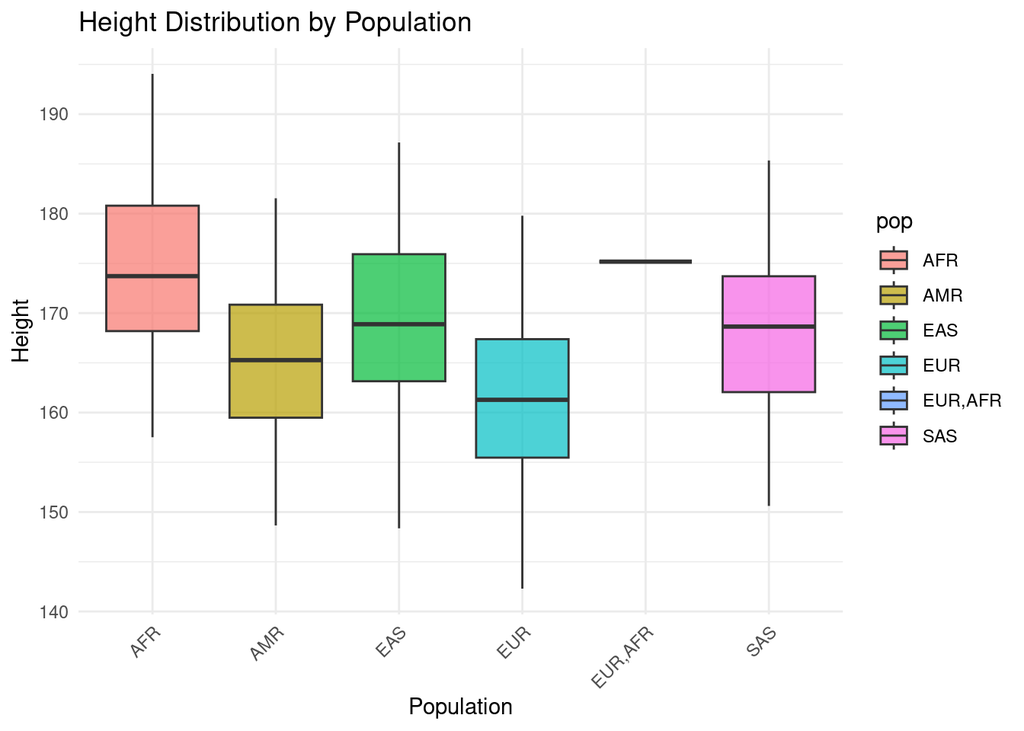

```r
ggplot(pData(sample.info), aes(x = pop, y = height, fill = pop)) +
  geom_boxplot(alpha = 0.7) +
  theme_minimal() +
  labs(title = "Height Distribution by Population", x = "Population", y = "Height") +
  theme(axis.text.x = element_text(angle = 45, hjust = 1))
```

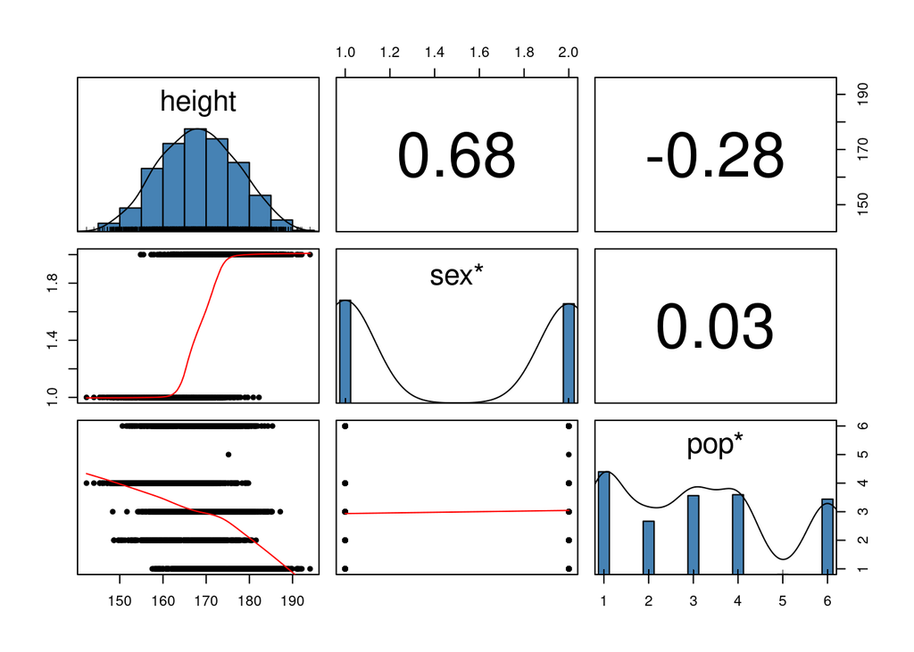

```r
pairs.panels(pData(sample.info)[, c("height","sex", "pop")], ellipses = FALSE, hist.col = "steelblue")
```

```r
#Part-0 qn-3 : Based on your findings, do you think you should include sex or pop as covariates in a GWAS for height?
#Ans-3 : Yes, sex and population should be included as covariates in GWAS for height.
```

## Part 1 - Imputed genotypes

Imputed genotypes were obtained using the TOPMed Imputation Server (and then downsampled for computational ease). Information about the resulting variants is in `p3_variant_info.RData`. The imputed genotypes themselves have been converted to a SNP GDS file, `p3_imputed_data.gds`.

Load in the SNP information file and explore it. The columns are:

- snp.id: the variant id used in the GDS
- chr: chromosome
- pos: position
- alleles: allele codes (ref, alt)
- af: alt allele frequency
- r2: imputation r-squared
- genotyped: TRUE if genotyped, FALSE if imputed

```r
# load in SNP information file
load(paste0(my_folder, "p3_variant_info.RData"), verbose = TRUE)
```

```
## Loading objects:
##   snp.info
```

```r
# counts of imputed vs. genotyped variants
snp.info %>% count(genotyped)
```

```
##   genotyped      n
## 1     FALSE 637620
## 2      TRUE  10009
```

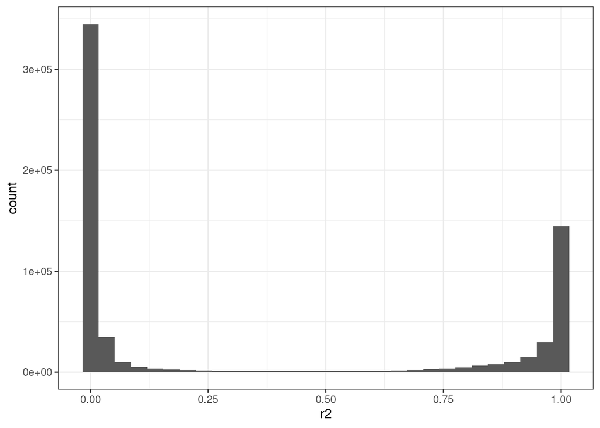

```r
# explore imputation quality r2
ggplot(data = snp.info, aes(x=r2)) +
  geom_histogram() +
  theme_bw()
```

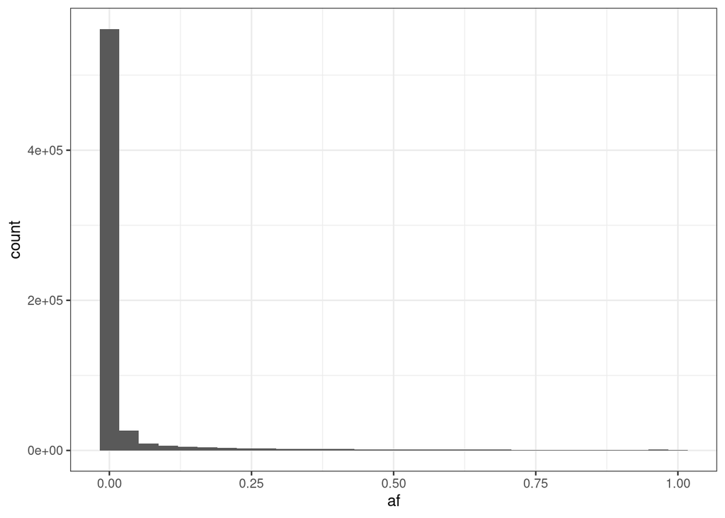

```r
# explore allele frequency
ggplot(data = snp.info, aes(x=af)) +
  geom_histogram() +
  theme_bw()
```

```r
snp.info %>% count(af == 0 | af == 1)
```

```
##   af == 0 | af == 1      n
## 1             FALSE 623882
## 2              TRUE  23747
```

Decide on reasonable filters for these SNPs to be included in a GWAS for this sample. Base this decision on your exploration of the `snp.info` and content from class. You will be guided to think about specific aspects for these filters in the reporting section below.

Create a list of SNPs to use for downstream analyses, implementing your chosen filters. **You will need to put your criteria for SNPs to include inside the `filter` function.** Running the template code as is will not perform any filtering.

```r
# make list of snp.ids for SNPs passing filters using snp.info
snps.keep <- snp.info %>% filter(r2 > 0.8 & af > 0.01 & af < 0.99) %>% pull(snp.id)
```